# Final Project

Wanjia Guo

12/9/2021

# Research problem

This kaggle dataset (https://www.kaggle.com/cosmos98/twitter-and-reddit-sentimental-analysis-dataset) contains clean text and sentiment of posts from Reddit and Twitter. Twitter also has way more data points than Reddit posts. Therefore, I think it would be interesting to train a ML model that can identify the sentiment for Twitter. Then, I will apply the model to the hold-out data from both Twitter and Reddit data to understand if the sentiment in Twitter can be generalized for Reddit comments. I think this is an interesting question no matter the performance of reddit comments is similar or worse than the twitter data. If the performance of twitter posts is way better than the performance of reddit comments, that means there are something that is not generalizable between twitter posts and reddit comments, and it would be interesting to find out what causes the differences. However, if the performance of the model is similar between twitter and redddit, then it means that the sentiment people convey are consistent and generalizable no matter where they are posting.

# Description of the data

```r
library(tidyverse)
reddit <- read.csv("./data/Reddit_Data.csv")
twitter <- read.csv("./data/Twitter_Data.csv")

head(reddit)
```

```
##                                                                                                                                                                                                                                                                                                          …
## 1                                                                                                                                                                                                                                                                                                        …
## 2 buddhism has very much lot compatible with christianity especially considering that sin and suffering are almost the same thing suffering caused wanting things shouldn want going about getting things the wrong way christian this would mean wanting things that don coincide with god will and want…
## 3                                                                                                                                                                                                                                                                                                        …
## 4                                                                                                                                                                                                                                                                                                        …
## 5                                                                                                                                                                                                                                                                                                        …
## 6                                                                                                                                                                                                                                                                                                        …
##   category
## 1        1
## 2        1
## 3       -1
## 4        0
## 5        1
## 6       -1
```

```r
head(twitter)
```

```
##                                                                                                                                                                                                             clean_text
## 1   when modi promised “minimum government maximum governance” expected him begin the difficult job reforming the state why does take years get justice state should and not business and should exit psus and temples
## 2                                                                                                                                                 talk all the nonsense and continue all the drama will vote for modi
## 3                                                                                                what did just say vote for modi  welcome bjp told you rahul the main campaigner for modi think modi should just relax
## 4 asking his supporters prefix chowkidar their names modi did great service now there confusion what read what not now crustal clear what will crass filthy nonsensical see how most abuses are coming from chowkidars
## 5                                                                                                                                    answer who among these the most powerful world leader today trump putin modi may
## 6                                                                                                                                                                             kiya tho refresh maarkefir comment karo
##   category
## 1       -1
## 2        0
## 3        1
## 4        1
## 5        1
## 6        0
```

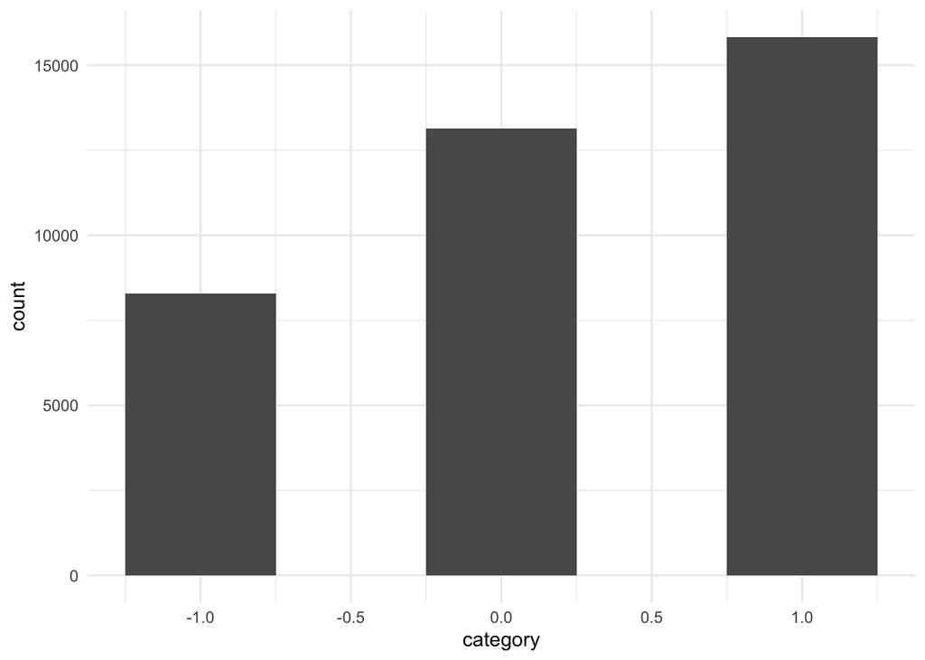

```r
ggplot(reddit, aes(x = category)) + geom_histogram(bins = 5) + theme_minimal()
```

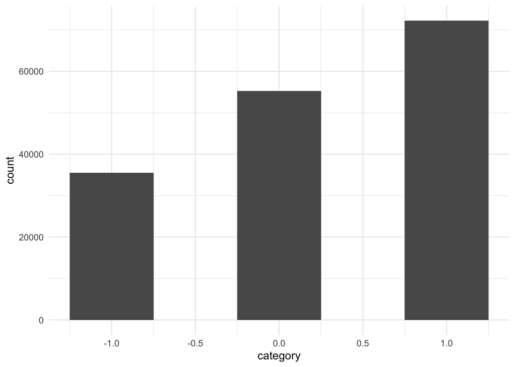

```r
ggplot(twitter, aes(x = category)) + geom_histogram(bins = 5) + theme_minimal()
```

For both twitter and reddit data, there are 2 columns. The first column is clean text, and the second column is the sentiment (-1: negative; 0: neutral; 1: positive). There is no missing data.

Secondly, the data is relatively large in size (with 162980 rows for twitter, and 37249 for reddit), and it will take a long time to process. I decided to perform a subsampling for the purpose of the current project.

```r
set.seed(315)

twitter_positive = twitter %>% filter(category == 1) %>% sample_n(500)
twitter_negative = twitter %>% filter(category == 0) %>% sample_n(500)

reddit_positive = reddit %>% filter(category == 1) %>% sample_n(125)
reddit_negative = reddit %>% filter(category == 0) %>% sample_n(125)
```

Then, I ran the NLP analysis on all 4 data sets to translate the sentences into numeric characters.

Loading necessary packages:

```r
library(reticulate)
path_to_env <- "/usr/local/anaconda3/envs/r.python/"
use_condaenv(path_to_env)
py_discover_config()

import('numpy')
import('transformers')
import('nltk')
import('torch')

library(text)
```

Performing NLP with roberta-base:

```r
t_positive = map(twitter_positive$clean_text, textEmbed,
                  model = 'roberta-base',
                  layers = 12,
                  context_aggregation_layers = 'concatenate')

t_negative = map(twitter_negative$clean_text, textEmbed,
                  model = 'roberta-base',
                  layers = 12,
                  context_aggregation_layers = 'concatenate')

r_positive = map(reddit_positive$clean_comment, textEmbed,
                  model = 'roberta-base',
                  layers = 12,
                  context_aggregation_layers = 'concatenate')

r_negative = map(reddit_negative$clean_comment, textEmbed,
                  model = 'roberta-base',
                  layers = 12,
                  context_aggregation_layers = 'concatenate')
```

Organizing dataframes and save the data locally:

```r
t_p = t(sapply(t_positive, `[[`, 1)) %>%
  data.frame()  %>%
  map_dfr(as.numeric) %>%
  mutate(sentiment = 1)

t_n = t(sapply(t_negative, `[[`, 1)) %>%
  data.frame()  %>%
  map_dfr(as.numeric) %>%
  mutate(sentiment = 0)

r_p = t(sapply(r_positive, `[[`, 1)) %>%
  data.frame()  %>%
  map_dfr(as.numeric) %>%
  mutate(sentiment = 1)

r_n = t(sapply(r_negative, `[[`, 1)) %>%
  data.frame()  %>%
  map_dfr(as.numeric) %>%
  mutate(sentiment = 0)

sub_twitter = rbind(t_p, t_n)
sub_reddit = rbind(r_p, r_n)

save(sub_twitter, file = "./data/sub_twitter.RData")
save(sub_reddit, file = "./data/sub_reddit.RData")
```

```r
set.seed(315)
remove("reddit")
remove("twitter")
```

Read in the processed data set from local file:

```r
load("./data/sub_twitter.RData")
load("./data/sub_reddit.RData")
```

```r
loc      <- sample(1:nrow(sub_twitter), round(nrow(sub_twitter) * 0.75))
twitter_train  <- sub_twitter[loc, ]
twitter_test  <- sub_twitter[-loc, ]
```

Now we have one data frame named ‘twitter_train’, that contains 750 rows of data for training. It has 768 columns of dimensions created from NLP, as well as one column that indicates the outcomes as either positive or negative.

# Description of the models

### Set up the blueprint and cross-validations

```r
library(caret)
library(recipes)
library(finalfit)
library(glmnet)
library(cutpointr)
library(ranger)
```

```r
blueprint <- recipe(x     = twitter_train,
                    vars  = colnames(twitter_train),
                    roles = c(rep('predictor',768),'outcome')) %>%
  step_zv(paste0('Dim',1:768)) %>%
  step_nzv(paste0('Dim',1:768)) %>%
  step_normalize(paste0('Dim',1:768)) %>%
  step_num2factor(sentiment,
                  transform = function(x) x + 1,
                  levels=c('Negative','Positive'))

# Cross validation settings

# Randomly shuffle the data

twitter_train = twitter_train[sample(nrow(twitter_train)),]

# Create 10 folds with equal size

folds = cut(seq(1,nrow(twitter_train)),breaks=10,labels=FALSE)

# Create the list for each fold

my.indices <- vector('list',10)
for(i in 1:10){
  my.indices[[i]] <- which(folds!=i)
}

cv <- trainControl(method    = "cv",
                   index           = my.indices,
                   classProbs      = TRUE,
                   summaryFunction = mnLogLoss)
```

### Logistic Regression (No Penalty)

```r
# Train the model

vanilla <- train(blueprint,
                data      = twitter_train,
                method    = "glmnet",
                family    = 'binomial',
                metric    = 'logLoss',
                trControl = cv)

save(vanilla, file = "./data/models/vanilla.RData")
```

```r
load(file = "./data/models/vanilla.RData")
```

### Logistic Regression (Elastic Net)

I secondly tired a elastic net logistic regression. The reason for choosing this model is because the vanilla model tends to cause overfitting issue. The elastic net contains two different kinds of penalty: and lasso, and the percentage of each penalty (alpha) is a hyperpameter that needs to be tested and decided. The other hyperparameter that needs to be tested is lambda, which indicates how strong the penalty is for large coefficients for features. Otherwise, it carries a very similar mechanisms as the vanilla logistic regression.

```r
grid <- expand.grid(alpha = seq(0,.8,.01), lambda = seq(0,.001,.001))

# Train the model

elastic <- train(blueprint,
                data      = twitter_train,
                method    = "glmnet",
                family    = 'binomial',
                metric    = 'logLoss',
                trControl = cv,
                tuneGrid  = grid)

save(elastic, file = "./data/models/elastic1.RData")
```

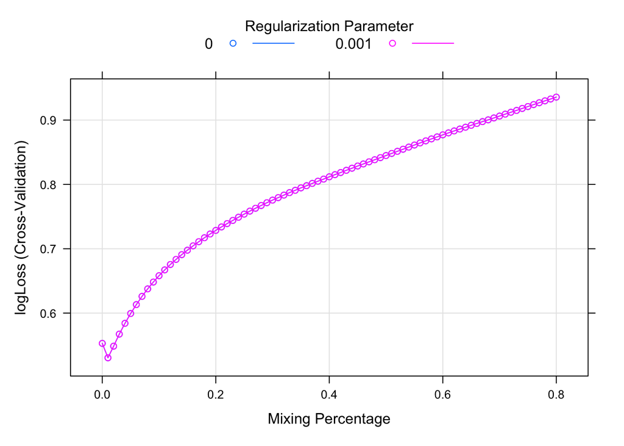

```r
load(file = "./data/models/elastic1.RData")

plot(elastic)
```

```r
elastic$bestTune
```

```
##   alpha lambda
## 4  0.01  0.001
```

From the previous model, we see that alpha = 0.01 and lambda = 0.001 gives the best results, but we only tried two different labmdas, so I will try another model with alpha fixed at 0.01, but test more lambdas.

```r
grid <- expand.grid(alpha = 0.01, lambda = seq(0,.1,.001))

# Train the model

elastic <- train(blueprint,
                data      = twitter_train,
                method    = "glmnet",
                family    = 'binomial',
                metric    = 'logLoss',
                trControl = cv,
                tuneGrid  = grid)

save(elastic, file = "./data/models/elastic2.RData")
```

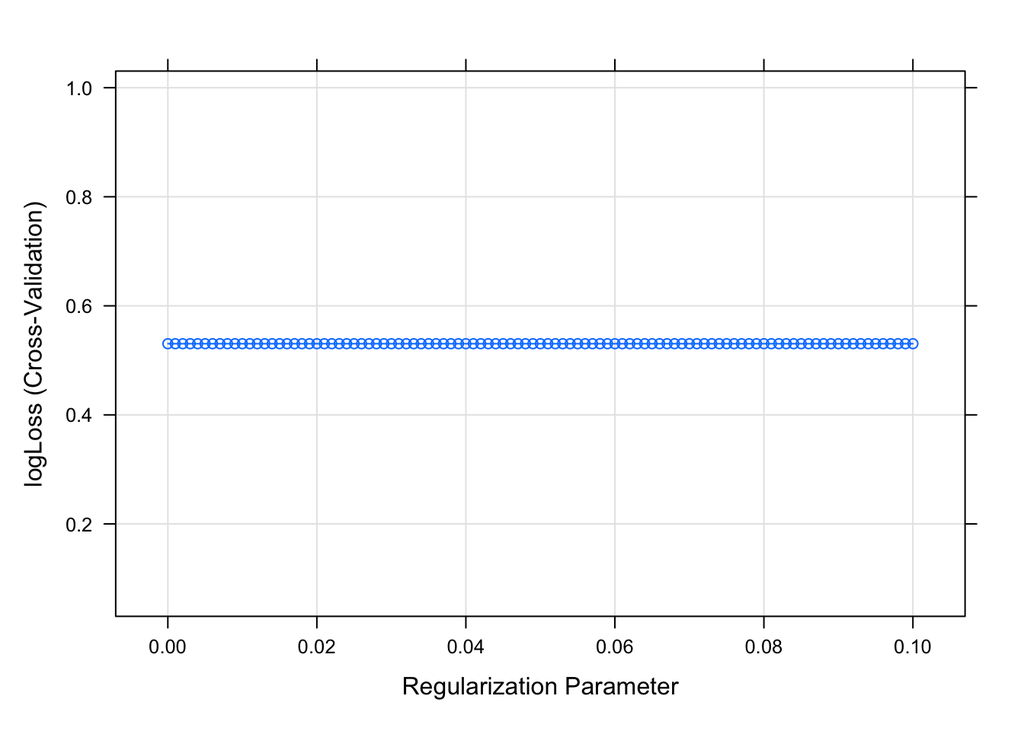

```r
load(file = "./data/models/elastic2.RData")

# check the results

plot(elastic)
```

```r
elastic$bestTune
```

```
##     alpha lambda
## 101  0.01    0.1
```

It seems like lambda does not have a big influence in model. We will proceed with alpha = 0.01, and lambda = 0.1 for the elastic net logistic model.

### Bagged tree

Next, I will test on a bagged tree Bagged tree is a type of tree model. The tree model will test all possible ways to separate data into various categories and decide the outcome through assigning each sample into a particular category based on the features. In addition to the vanilla tree model, the bagged tree utilize bootstraping for the data points and use only a subset of data for each tree, with a lot of trees in total. Through aggregating over all trees, each with a different subset of the sample, the bagged tree achieved a better ability in generalization than normal tree models. The most important hyperparameter that we need to adjust for bagged tree models is the number of trees.

```r
grid <- expand.grid(mtry = ncol(twitter_train)-1,
                    splitrule='gini',
                    min.node.size=2)

bags <- vector('list',7)

for(i in c(10,50,100,200,300,400,500)){

  bags[[i]] <- caret::train(blueprint,
                            data      = twitter_train,
                            method    = 'ranger',
                            trControl = cv,
                            tuneGrid  = grid,
                            metric = 'logLoss',
                            num.trees = i,
                            max.depth = 60)
}

bags = bags[lengths(bags) != 0]

save(bags, file = "./data/models/bags.RData")
```

```r
load(file = "./data/models/bags.RData")

logLoss_ <- c()

for(i in 1:7){

  logLoss_[i] = bags[[i]]$results$logLoss

}

logLoss_
```

```
## [1] 1.0571948 0.5881824 0.5782799 0.5739483 0.5765870 0.5731590 0.5746991
```

```r
which.min(logLoss_)
```

```
## [1] 6
```

Out of all 7 models I tried, the model with 400 trees achieved the lowest loss, or best results.

# Model fit

I will calculate the Logloss, AUC, ACC, TPR, TNR, and PRE for each model. The cut off is 0.5 because when I take sample from the data, I choose equal amount of positive and negative posts.

### Logistic Regression (No penalty)

Predict twitter data:

```r
twitter_vanilla_predicted <- predict(vanilla, twitter_test, type='prob')

cut.obj <- cutpointr(x     = twitter_vanilla_predicted$Positive,
                     class = twitter_test$sentiment)
```

```
## Assuming the positive class is 1
```

```
## Assuming the positive class has higher x values
```

```r
twitter_vanilla_auc = auc(cut.obj)

twitter_vanilla_auc
```

```
## [1] 0.9012917
```

```r
# Confusion matrix

twitter_vanilla_pred_class <- ifelse(twitter_vanilla_predicted$Positive>.5,1,0)

twitter_vanilla_confusion <- table(twitter_test$sentiment,twitter_vanilla_pred_class)

twitter_vanilla_confusion
```

```
##    twitter_vanilla_pred_class
##       0   1
##   0  90  27
##   1  20 113
```

```r
twitter_vanilla_ACC = (twitter_vanilla_confusion[2,2]+twitter_vanilla_confusion[1,1])/sum(twitter_vanilla_confusion)

twitter_vanilla_ACC
```

```
## [1] 0.812
```

```r
twitter_vanilla_TPR = twitter_vanilla_confusion[2,2]/(twitter_vanilla_confusion[2,1]+twitter_vanilla_confusion[2,2])

twitter_vanilla_TPR
```

```
## [1] 0.8496241
```

```r
twitter_vanilla_TNR = twitter_vanilla_confusion[1,1]/(twitter_vanilla_confusion[1,1]+twitter_vanilla_confusion[1,2])

twitter_vanilla_TNR
```

```
## [1] 0.7692308
```

```r
twitter_vanilla_PRE = twitter_vanilla_confusion[2,2]/(twitter_vanilla_confusion[1,2]+twitter_vanilla_confusion[2,2])

twitter_vanilla_PRE
```

```
## [1] 0.8071429
```

Predict reddit data:

```r
reddit_vanilla_predicted_reddit <- predict(vanilla, sub_reddit, type='prob')

cut.obj <- cutpointr(x     = reddit_vanilla_predicted_reddit$Positive,
                     class = sub_reddit$sentiment)
```

```
## Assuming the positive class is 1
```

```
## Assuming the positive class has higher x values
```

```
## Multiple optimal cutpoints found, applying break_ties.
```

```r
reddit_vanilla_auc = auc(cut.obj)

reddit_vanilla_auc
```

```
## [1] 0.83072
```

```r
# Confusion matrix

reddit_pred_class <- ifelse(reddit_vanilla_predicted_reddit$Positive>.5,1,0)

reddit_vanilla_confusion <- table(sub_reddit$sentiment,reddit_pred_class)

reddit_vanilla_confusion
```

```
##    reddit_pred_class
##      0  1
##   0 99 26
##   1 33 92
```

```r
reddit_vanilla_ACC = (reddit_vanilla_confusion[2,2]+reddit_vanilla_confusion[1,1])/sum(reddit_vanilla_confusion)

reddit_vanilla_ACC
```

```
## [1] 0.764
```

```r
reddit_vanilla_TPR = reddit_vanilla_confusion[2,2]/(reddit_vanilla_confusion[2,1]+reddit_vanilla_confusion[2,2])

reddit_vanilla_TPR
```

```
## [1] 0.736
```

```r
reddit_vanilla_TNR = reddit_vanilla_confusion[1,1]/(reddit_vanilla_confusion[1,1]+reddit_vanilla_confusion[1,2])

reddit_vanilla_TNR
```

```
## [1] 0.792
```

```r
reddit_vanilla_PRE = reddit_vanilla_confusion[2,2]/(reddit_vanilla_confusion[1,2]+reddit_vanilla_confusion[2,2])

reddit_vanilla_PRE
```

```
## [1] 0.779661
```

### Logistic Regression (Elastic Net)

Predict twitter data:

```r
twitter_elastic_predicted <- predict(elastic, twitter_test, type='prob')

cut.obj <- cutpointr(x     = twitter_elastic_predicted$Positive,
                     class = twitter_test$sentiment)
```

```
## Assuming the positive class is 1
```

```
## Assuming the positive class has higher x values
```

```r
twitter_elastic_auc = auc(cut.obj)

twitter_elastic_auc
```

```
## [1] 0.9220487
```

```r
# Confusion matrix

twitter_elastic_pred_class <- ifelse(twitter_elastic_predicted$Positive>.5,1,0)

twitter_elastic_confusion <- table(twitter_test$sentiment,twitter_elastic_pred_class)

twitter_elastic_confusion
```

```
##    twitter_elastic_pred_class
##       0   1
##   0  94  23
##   1  17 116
```

```r
twitter_elastic_ACC = (twitter_elastic_confusion[2,2]+twitter_elastic_confusion[1,1])/sum(twitter_elastic_confusion)

twitter_elastic_ACC
```

```
## [1] 0.84
```

```r
twitter_elastic_TPR = twitter_elastic_confusion[2,2]/(twitter_elastic_confusion[2,1]+twitter_elastic_confusion[2,2])

twitter_elastic_TPR
```

```
## [1] 0.8721805
```

```r
twitter_elastic_TNR = twitter_elastic_confusion[1,1]/(twitter_elastic_confusion[1,1]+twitter_elastic_confusion[1,2])

twitter_elastic_TNR
```

```
## [1] 0.8034188
```

```r
twitter_elastic_PRE = twitter_elastic_confusion[2,2]/(twitter_elastic_confusion[1,2]+twitter_elastic_confusion[2,2])

twitter_elastic_PRE
```

```
## [1] 0.8345324
```

Predict reddit data:

```r
reddit_elastic_predicted <- predict(elastic, sub_reddit, type='prob')

cut.obj <- cutpointr(x     = reddit_elastic_predicted$Positive,
                     class = sub_reddit$sentiment)
```

```
## Assuming the positive class is 1
```

```
## Assuming the positive class has higher x values
```

```
## Multiple optimal cutpoints found, applying break_ties.
```

```r
reddit_elastic_auc = auc(cut.obj)

reddit_elastic_auc
```

```
## [1] 0.836032
```

```r
# Confusion matrix

reddit_elastic_pred_class <- ifelse(reddit_elastic_predicted$Positive>.5,1,0)

reddit_elastic_confusion <- table(sub_reddit$sentiment,reddit_elastic_pred_class)

reddit_elastic_confusion
```

```
##    reddit_elastic_pred_class
##       0   1
##   0 101  24
##   1  35  90
```

```r
reddit_elastic_ACC = (reddit_elastic_confusion[2,2]+reddit_elastic_confusion[1,1])/sum(reddit_elastic_confusion)

reddit_elastic_ACC
```

```
## [1] 0.764
```

```r
reddit_elastic_TPR = reddit_elastic_confusion[2,2]/(reddit_elastic_confusion[2,1]+reddit_elastic_confusion[2,2])

reddit_elastic_TPR
```

```
## [1] 0.72
```

```r
reddit_elastic_TNR = reddit_elastic_confusion[1,1]/(reddit_elastic_confusion[1,1]+reddit_elastic_confusion[1,2])

reddit_elastic_TNR
```

```
## [1] 0.808
```

```r
reddit_elastic_PRE = reddit_elastic_confusion[2,2]/(reddit_elastic_confusion[1,2]+reddit_elastic_confusion[2,2])

reddit_elastic_PRE
```

```
## [1] 0.7894737
```

### Bagged tree

Predict twitter data:

```r
twitter_bag_predicted <- predict(bags[[6]], twitter_test, type='prob')

cut.obj <- cutpointr(x     = twitter_bag_predicted$Positive,
                     class = twitter_test$sentiment)
```

```
## Assuming the positive class is 1
```

```
## Assuming the positive class has higher x values
```

```r
twitter_bag_auc = auc(cut.obj)

twitter_bag_auc
```

```
## [1] 0.990489
```

```r
# Confusion matrix

twitter_bag_pred_class <- ifelse(twitter_bag_predicted$Positive>.5,1,0)

twitter_bag_confusion <- table(twitter_test$sentiment,twitter_bag_pred_class)

twitter_bag_confusion
```

```
##    twitter_bag_pred_class
##       0   1
##   0 106  11
##   1   5 128
```

```r
twitter_bag_ACC = (twitter_bag_confusion[2,2]+twitter_bag_confusion[1,1])/sum(twitter_bag_confusion)

twitter_bag_ACC
```

```
## [1] 0.936
```

```r
twitter_bag_TPR = twitter_bag_confusion[2,2]/(twitter_bag_confusion[2,1]+twitter_bag_confusion[2,2])

twitter_bag_TPR
```

```
## [1] 0.962406
```

```r
twitter_bag_TNR = twitter_bag_confusion[1,1]/(twitter_bag_confusion[1,1]+twitter_bag_confusion[1,2])

twitter_bag_TNR
```

```
## [1] 0.9059829
```

```r
twitter_bag_PRE = twitter_bag_confusion[2,2]/(twitter_bag_confusion[1,2]+twitter_bag_confusion[2,2])

twitter_bag_PRE
```

```
## [1] 0.9208633
```

Predict reddit data:

```r
reddit_bag_predicted <- predict(bags[[6]], sub_reddit, type='prob')

cut.obj <- cutpointr(x     = reddit_bag_predicted$Positive,
                     class = sub_reddit$sentiment)
```

```
## Assuming the positive class is 1
```

```
## Assuming the positive class has higher x values
```

```
## Multiple optimal cutpoints found, applying break_ties.
```

```r
reddit_bag_auc = auc(cut.obj)

reddit_bag_auc
```

```
## [1] 0.781536
```

```r
# Confusion matrix

reddit_bag_pred_class <- ifelse(reddit_bag_predicted$Positive>.5,1,0)

reddit_bag_confusion <- table(sub_reddit$sentiment,reddit_bag_pred_class)

reddit_bag_confusion
```

```
##    reddit_bag_pred_class
##      0  1
##   0 96 29
##   1 50 75
```

```r
reddit_bag_ACC = (reddit_bag_confusion[2,2]+reddit_bag_confusion[1,1])/sum(reddit_bag_confusion)

reddit_bag_ACC
```

```
## [1] 0.684
```

```r
reddit_bag_TPR = reddit_bag_confusion[2,2]/(reddit_bag_confusion[2,1]+reddit_bag_confusion[2,2])

reddit_bag_TPR
```

```
## [1] 0.6
```

```r
reddit_bag_TNR = reddit_bag_confusion[1,1]/(reddit_bag_confusion[1,1]+reddit_bag_confusion[1,2])

reddit_bag_TNR
```

```
## [1] 0.768
```

```r
reddit_bag_PRE = reddit_bag_confusion[2,2]/(reddit_bag_confusion[1,2]+reddit_bag_confusion[2,2])

reddit_bag_PRE
```

```
## [1] 0.7211538
```

```r
model_name <- c('Logistic Regression', 'Logistic Regression', 'Elastic Net', 'Elastic Net', 'Bagged Tree', 'Bagged Tree')
predicted <- c('twitter', 'reddit', 'twitter', 'reddit', 'twitter', 'reddit')

LL <- c(vanilla$results$logLoss %>% min(),
        vanilla$results$logLoss %>% min(),
        elastic$results %>% filter(lambda == elastic$bestTune$lambda) %>% .$logLoss,
        elastic$results %>% filter(lambda == elastic$bestTune$lambda) %>% .$logLoss,
        bags[[6]]$results$logLoss,
        bags[[6]]$results$logLoss)
AUC <- c(twitter_vanilla_auc, reddit_vanilla_auc, twitter_elastic_auc,
         reddit_elastic_auc, twitter_bag_auc, reddit_bag_auc)
ACC <- c(twitter_vanilla_ACC, reddit_vanilla_ACC, twitter_elastic_ACC,
         reddit_elastic_ACC, twitter_bag_ACC, reddit_bag_ACC)
TPR <- c(twitter_vanilla_TPR, reddit_vanilla_TPR, twitter_elastic_TPR,
         reddit_elastic_TPR, twitter_bag_TPR, reddit_bag_TPR)
TNR <- c(twitter_vanilla_TNR, reddit_vanilla_TNR, twitter_elastic_TNR,
         reddit_elastic_TNR, twitter_bag_TNR, reddit_bag_TNR)
PRE <- c(twitter_vanilla_PRE, reddit_vanilla_PRE, twitter_elastic_PRE,
         reddit_elastic_PRE, twitter_bag_PRE, reddit_bag_PRE)

summary_df <- data.frame(model_name, predicted, LL, AUC, ACC, TPR, TNR, PRE)

summary_df
```

```
##            model_name predicted        LL       AUC   ACC       TPR       TNR
## 1 Logistic Regression   twitter 0.5326567 0.9012917 0.812 0.8496241 0.7692308
## 2 Logistic Regression    reddit 0.5326567 0.8307200 0.764 0.7360000 0.7920000
## 3         Elastic Net   twitter 0.5305089 0.9220487 0.840 0.8721805 0.8034188
## 4         Elastic Net    reddit 0.5305089 0.8360320 0.764 0.7200000 0.8080000
## 5         Bagged Tree   twitter 0.5731590 0.9904890 0.936 0.9624060 0.9059829
## 6         Bagged Tree    reddit 0.5731590 0.7815360 0.684 0.6000000 0.7680000
##         PRE
## 1 0.8071429
## 2 0.7796610
## 3 0.8345324
## 4 0.7894737
## 5 0.9208633
## 6 0.7211538
```

# Data visualization

# Discussion / Conclusion

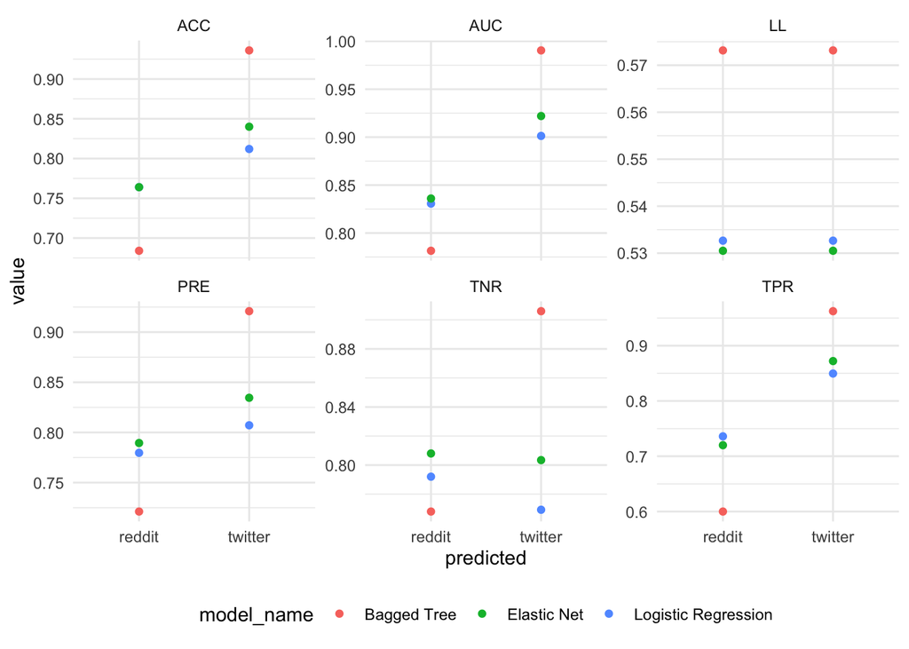

```r
summary_df_long = summary_df %>% pivot_longer(cols = LL:PRE, names_to = 'type', values_to = 'value')

ggplot(summary_df_long, aes(x = predicted, y = value, color = model_name)) +
  geom_point() +
  facet_wrap(~type, scales = 'free_y')+
  theme_minimal()+
  theme(legend.position = 'bottom')
```

I found these results really interesting. It seems like overall, the performance of twitter is either similar to or better than the reddit. It makes sense because all models are trained solely on twitter posts data. Therefore, the data taken from the same source (also twitter posts) also have better performance than data taken from a different posts (reddit posts in this example). however, the differences between twitter and reddit are really not as big as I expected! Across 3 models I tried, bagged model performed extremely well for twitter data, but it probably suffered from overfitting as the performance is also the worst for reddit data. Overall, elastic net has the best performance when considering both the reddit and twitter data predictions. Regarding the important features, because I transformed the sentence data into NLP dimentions, the meaning of the dimentions is not really intepretable.

# Reproducibility

**This script include ‘eval = FALSE’ for some sections, mostly the NLP transformation and model fitting, to save the run time across re-knit. The NLP transformation results are in included in the data folder, but the model fitting results are not, due to their sizes. If you see a line of code that load from ‘./data/models/’, then the code will not run. Instead, please change the eval of the previous R section into TRUE to run and save the corresponding model locally.**